# Entrega grupal II

Aplicando KNN, Árbol, Random Forest y regresión logística a titanic.csv

Iván González, Qiqi Zhou y Felipe Reyes (Universidad Complutense de Madrid)https://ucm.es  
2023-01-15

# Objetivo

El objetivo de esta práctica es **clasificar** a los pasajeros que **sobrevivieron** al **accidente del transatlántico RMS Titanic** de aquellos que **no lo lograron** a través de distintos **algoritmos de clasificación**.

## Paquetes necesarios

Necesitaremos los siguientes paquetes:

```r
# Borramos
rm(list = ls())

# Paquetes
library(skimr) # Resumen numérico
library(tidymodels) # Depuración datos
library(tidyverse) # Modelos
library(outliers) # Outliers
library(themis) # Sobremuestreo
library(parallel) # Fase de validación
library(doParallel) # Fase de validación
library(rpart.plot) # Visualización de árboles
library(ggthemes)
library(glue)
library(ranger) # Random Forest
library(vip)
```

# Datos

Los datos que usaremos provienen del **dataset titanic_train.csv**.

```r
titanic_bruto <- read_csv(file = "/Users/leztin/Desktop/DATOS/titanic_train.csv")
```

## Análisis exploratorio inicial (numérico)

Antes de tomar cualquier decisión con los datos, lo primero que haremos será **echar un vistazo numérico** a cómo se comportan las variables. Dado que vamos a clasificar, en primer lugar comprobaremos **cómo se distribuyen** los niveles de nuestra **variable objetivo**.

### Variables

Lo primero es conocer nuestras variables.

```r
glimpse(titanic_bruto)
```

```
Rows: 891
Columns: 12
$ PassengerId <dbl> 1, 2, 3, 4, 5, 6, 7, 8, 9, 10, 11, 12, 13, 14, 1…
$ Survived    <dbl> 0, 1, 1, 1, 0, 0, 0, 0, 1, 1, 1, 1, 0, 0, 0, 1, …
$ Pclass      <dbl> 3, 1, 3, 1, 3, 3, 1, 3, 3, 2, 3, 1, 3, 3, 3, 2, …
$ Name        <chr> "Braund, Mr. Owen Harris", "Cumings, Mrs. John B…
$ Sex         <chr> "male", "female", "female", "female", "male", "m…
$ Age         <dbl> 22, 38, 26, 35, 35, NA, 54, 2, 27, 14, 4, 58, 20…
$ SibSp       <dbl> 1, 1, 0, 1, 0, 0, 0, 3, 0, 1, 1, 0, 0, 1, 0, 0, …
$ Parch       <dbl> 0, 0, 0, 0, 0, 0, 0, 1, 2, 0, 1, 0, 0, 5, 0, 0, …
$ Ticket      <chr> "A/5 21171", "PC 17599", "STON/O2. 3101282", "11…
$ Fare        <dbl> 7.2500, 71.2833, 7.9250, 53.1000, 8.0500, 8.4583…
$ Cabin       <chr> NA, "C85", NA, "C123", NA, NA, "E46", NA, NA, NA…
$ Embarked    <chr> "S", "C", "S", "S", "S", "Q", "S", "S", "S", "C"…
```

- `PassengerId`: ID del pasajero.
- `Survived`: ¿el pasajero sobrevivió o no? (0 = No / 1 = Sí)
- `Pclass`: clases de ticket (primera, segunda y tercera clase).
- `Name`: nombre del pasajero.
- `Sex`: sexo del pasajero.
- `Age`: edad del pasajero.
- `SibSp`: número de hermanos y cónyuges a bordo de la embarcación.
- `Parch`: número de padres e hijos a bordo de la embarcación
- `Ticket`: número del ticket.
- `Fare`: tarifa del pasajero.
- `Cabin`: número de camarote.
- `Embarked`: puerta de embarque (Cherbourg, Queenstown o Southampton).

### Balance de la variable objetivo

El objetivo será **predecir si un sobrevivió al accidente**, por lo que `Survived` será nuestra **variable objetivo**. En primer lugar comprobaremos cómo se **distribuyen los niveles de la objetivo**, que además es una variable binaria.

```r
# Objetivo: predecir si un pasajero sobrevivió al accidente del transatlántico RMS Titanic o no
titanic_bruto |>
  count(Survived) |>
  mutate(porc = 100 * n / sum(n))
```

```
# A tibble: 2 × 3
  Survived     n  porc
     <dbl> <int> <dbl>
1        0   549  61.6
2        1   342  38.4
```

Graficaremos estas proporciones a través de un gráfico de barras:

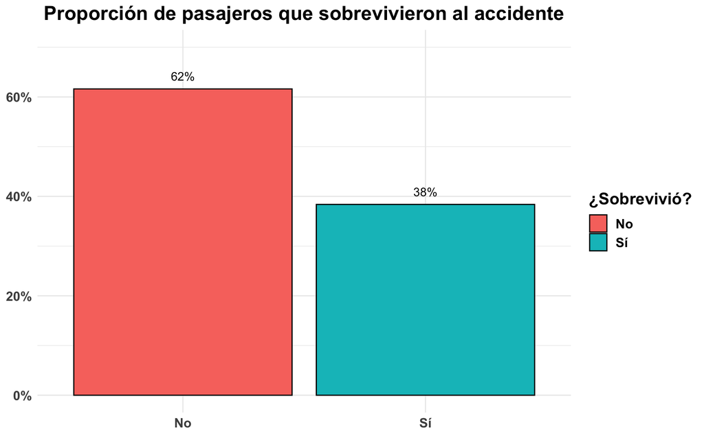

```r
titanic_bruto |>
  mutate(Survived = as.factor(Survived)) |>
  count(Survived) |>
  mutate(porc = n / sum(n)) |>
  ggplot(aes(Survived, porc, fill = Survived)) +
  geom_col(position = "dodge", color = "black") +
  scale_y_continuous(labels = scales::percent_format(), limit = c(0,0.7)) +
  labs(title = "Proporción de pasajeros que sobrevivieron al accidente", x = NULL, y = NULL) +
  theme_minimal() +
  theme(text = element_text(face = "bold", size = 15), plot.title = element_text(hjust = 0.5)) +
  scale_fill_discrete(name = "¿Sobrevivió?", labels = c("No", "Sí")) +
  geom_text(aes(label = scales::percent(porc)), position = position_dodge(width = 0.9), vjust = -1) +
  scale_x_discrete(labels = c("0" = "No","1" = "Sí"))
```

# Fase 2: Exploración de los datos

## Variables tipo texto, variables numéricas y factores

Tras esta pequeña aproximación al dataset, comienza la **primera fase** de la metodología SEMMA para el depurado de nuestros datos. En este primer apartado comprobaremos que todas las variables estén codificadas en su **tipología correcta**: debemos decidir si las variables de tipo texto son **variables cualitativas** (factores) o meros id’s.

```r
titanic_bruto |>
  select(where(is.numeric)) |>
  glimpse()
```

```
Rows: 891
Columns: 7
$ PassengerId <dbl> 1, 2, 3, 4, 5, 6, 7, 8, 9, 10, 11, 12, 13, 14, 1…
$ Survived    <dbl> 0, 1, 1, 1, 0, 0, 0, 0, 1, 1, 1, 1, 0, 0, 0, 1, …
$ Pclass      <dbl> 3, 1, 3, 1, 3, 3, 1, 3, 3, 2, 3, 1, 3, 3, 3, 2, …
$ Age         <dbl> 22, 38, 26, 35, 35, NA, 54, 2, 27, 14, 4, 58, 20…
$ SibSp       <dbl> 1, 1, 0, 1, 0, 0, 0, 3, 0, 1, 1, 0, 0, 1, 0, 0, …
$ Parch       <dbl> 0, 0, 0, 0, 0, 0, 0, 1, 2, 0, 1, 0, 0, 5, 0, 0, …
$ Fare        <dbl> 7.2500, 71.2833, 7.9250, 53.1000, 8.0500, 8.4583…
```

Encontramos en el dataset que **algunas** de las **variables numéricas** representan categorías que pueden expresarse como **cualitativas**. Las variables `Survived`, `Pclass`, `SibSp` y `Parch` toman valores únicos de, como máximo, **siete categorías**, por lo que podemos transformarlas a variables tipo texto y luego a factor para mayores facilidades en su manipulación. Modificamos en primer lugar esta cuestión:

```r
titanic <-
  titanic_bruto |>
  mutate(Survived = as.character(Survived),
         Pclass = as.character(Pclass),
         SibSp = as.character(SibSp),
         Parch = as.character(Parch))
titanic |>
  glimpse()
```

```
Rows: 891
Columns: 12
$ PassengerId <dbl> 1, 2, 3, 4, 5, 6, 7, 8, 9, 10, 11, 12, 13, 14, 1…
$ Survived    <chr> "0", "1", "1", "1", "0", "0", "0", "0", "1", "1"…
$ Pclass      <chr> "3", "1", "3", "1", "3", "3", "1", "3", "3", "2"…
$ Name        <chr> "Braund, Mr. Owen Harris", "Cumings, Mrs. John B…
$ Sex         <chr> "male", "female", "female", "female", "male", "m…
$ Age         <dbl> 22, 38, 26, 35, 35, NA, 54, 2, 27, 14, 4, 58, 20…
$ SibSp       <chr> "1", "1", "0", "1", "0", "0", "0", "3", "0", "1"…
$ Parch       <chr> "0", "0", "0", "0", "0", "0", "0", "1", "2", "0"…
$ Ticket      <chr> "A/5 21171", "PC 17599", "STON/O2. 3101282", "11…
$ Fare        <dbl> 7.2500, 71.2833, 7.9250, 53.1000, 8.0500, 8.4583…
$ Cabin       <chr> NA, "C85", NA, "C123", NA, NA, "E46", NA, NA, NA…
$ Embarked    <chr> "S", "C", "S", "S", "S", "Q", "S", "S", "S", "C"…
```

Ahora sí, todas las variables tipo texto representan **categorías de una cualitativa**, por lo que las convertimos todas ellas a **factor**.

```r
titanic <-
  titanic |>
  mutate(across(where(is.character), as_factor))
titanic |>
  glimpse()
```

```
Rows: 891
Columns: 12
$ PassengerId <dbl> 1, 2, 3, 4, 5, 6, 7, 8, 9, 10, 11, 12, 13, 14, 1…
$ Survived    <fct> 0, 1, 1, 1, 0, 0, 0, 0, 1, 1, 1, 1, 0, 0, 0, 1, …
$ Pclass      <fct> 3, 1, 3, 1, 3, 3, 1, 3, 3, 2, 3, 1, 3, 3, 3, 2, …
$ Name        <fct> "Braund, Mr. Owen Harris", "Cumings, Mrs. John B…
$ Sex         <fct> male, female, female, female, male, male, male, …
$ Age         <dbl> 22, 38, 26, 35, 35, NA, 54, 2, 27, 14, 4, 58, 20…
$ SibSp       <fct> 1, 1, 0, 1, 0, 0, 0, 3, 0, 1, 1, 0, 0, 1, 0, 0, …
$ Parch       <fct> 0, 0, 0, 0, 0, 0, 0, 1, 2, 0, 1, 0, 0, 5, 0, 0, …
$ Ticket      <fct> A/5 21171, PC 17599, STON/O2. 3101282, 113803, 3…
$ Fare        <dbl> 7.2500, 71.2833, 7.9250, 53.1000, 8.0500, 8.4583…
$ Cabin       <fct> NA, C85, NA, C123, NA, NA, E46, NA, NA, NA, G6, …
$ Embarked    <fct> S, C, S, S, S, Q, S, S, S, C, S, S, S, S, S, S, …
```

### Factores ordinales

La variable `Pclass`, además de **factor**, también puede seguir una **jerarquía** ordinal: `3` < `2` < `1`. De esta manera, ordenaríamos los tickets en función de su **clase** (1ª, 2ª y 3ª clase).

```r
titanic |>
  count(Pclass) |>
  mutate(porc = 100*n/sum(n))
```

```
# A tibble: 3 × 3
  Pclass     n  porc
  <fct>  <int> <dbl>
1 3        491  55.1
2 1        216  24.2
3 2        184  20.7
```

Convertimos `Pclass` a cualitativa pero ordinal.

```r
titanic <-
  titanic |>
  mutate(Pclass = factor(Pclass, levels = c("3", "2", "1"),
                       ordered = TRUE))
```

## Variables cualitativas

### Variable Survived

```r
titanic |>
  count(Survived, sort = TRUE) |>
  mutate(porc = 100*n/sum(n))
```

```
# A tibble: 2 × 3
  Survived     n  porc
  <fct>    <int> <dbl>
1 0          549  61.6
2 1          342  38.4
```

La variable `Survived` es una variable **binaria** y nuestra variable **objetivo**, por lo que la **mantendremos** tal y como está.

### Variable Pclass

```r
titanic |>
  count(Pclass, sort = TRUE) |>
  mutate(porc = 100*n/sum(n))
```

```
# A tibble: 3 × 3
  Pclass     n  porc
  <ord>  <int> <dbl>
1 3        491  55.1
2 1        216  24.2
3 2        184  20.7
```

La variable `Pclass` presenta **3 modalidades**. Además, **una** de ellas acapara el **55 %** del total de los registros. Comprobemos ahora su afectación sobre nuestra variable objetivo.

```r
titanic |>
  group_by(Pclass) |>
  count(Survived) |>
  mutate(porc = 100*n/sum(n)) |>
  ungroup()
```

```
# A tibble: 6 × 4
  Pclass Survived     n  porc
  <ord>  <fct>    <int> <dbl>
1 3      0          372  75.8
2 3      1          119  24.2
3 2      0           97  52.7
4 2      1           87  47.3
5 1      0           80  37.0
6 1      1          136  63.0
```

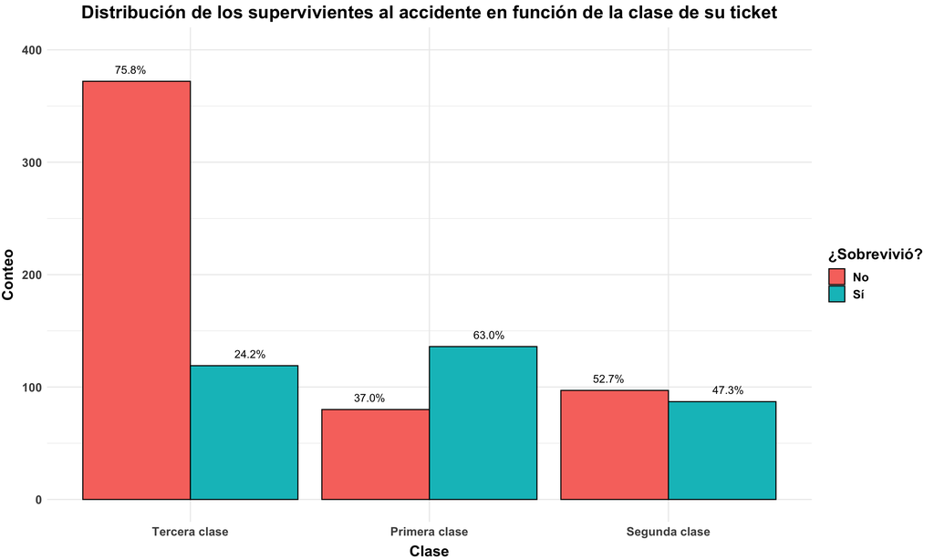

```r
titanic |>
  group_by(Pclass) |>
  count(Survived) |>
  mutate(porc = n / sum(n)) |>
  mutate(conteo = n) |>
  ggplot(aes(x = reorder(Pclass, -conteo), y = conteo, fill = Survived)) +
  geom_col(position = "dodge", color = "black") +
  labs(title = "Distribución de los supervivientes al accidente en función de la clase de su ticket", x = "Clase", y = "Conteo") +
  scale_y_continuous(limit = c(0,400)) +
  theme_minimal() +
  theme(text = element_text(face = "bold", size = 15), plot.title = element_text(hjust = 0.5),
  axis.title.x = element_text(vjust = -0.5), axis.title.y = element_text(vjust = 2)) +
  scale_fill_discrete(name = "¿Sobrevivió?", labels = c("No", "Sí")) +
  geom_text(aes(label = scales::percent(porc)), position = position_dodge(width = 1), vjust = -1) +
  scale_x_discrete(labels = c("1" = "Primera clase","2" = "Segunda clase", "3" = "Tercera clase"))
```

Algunas apreciaciones a la luz del gráfico:

- La variable se relaciona con nuestra variable objetivo de una forma **muy interesante**. En este sentido, se puede establecer una **relación directa** entre **clase** y **probabilidad de supervivencia**.
- La categoría `3` (tercera clase), a parte de ser la mayoritaria, también es la peor a nivel de supervivencia: **más del 70 %** de los pasajeros de tercera clase, **fallecieron en el accidente**.
- La categoría `2` (segunda clase) es la minoritaria (20 % sobre el total de los registros de la variable). En su caso, la distribución respecto de nuestra variable objetivo está **bastante igualada**, reduciéndose en un **20 %** la probabilidad de **muerte** en comparación con los pasajeros de tercera clase.
- La categoría `1` (primera clase) es la única clase en la que **la proporción de supervivientes supera a la de fallecidos**. Ello puede ser debido a que los camarotes en los que se encontraban la noche en la que sucedió la colisión eran más **amplios** o estaban **mejor situados** y tardaron más en hundirse que los camarotes del resto de clases. También es posible que los **botes salvavidas** y la **cubierta de botes** se encontraran **más cercanos** a los mejores camarotes que al resto.

Con ello en mente, se optará en la fase de **recategorización** por **mantener** las tres categorías.

### Variable Name

```r
titanic |>
  count(Name, sort = TRUE) |>
  mutate(porc = 100*n/sum(n))
```

```
# A tibble: 891 × 3
   Name                                                    n  porc
   <fct>                                               <int> <dbl>
 1 Braund, Mr. Owen Harris                                 1 0.112
 2 Cumings, Mrs. John Bradley (Florence Briggs Thayer)     1 0.112
 3 Heikkinen, Miss. Laina                                  1 0.112
 4 Futrelle, Mrs. Jacques Heath (Lily May Peel)            1 0.112
 5 Allen, Mr. William Henry                                1 0.112
 6 Moran, Mr. James                                        1 0.112
 7 McCarthy, Mr. Timothy J                                 1 0.112
 8 Palsson, Master. Gosta Leonard                          1 0.112
 9 Johnson, Mrs. Oscar W (Elisabeth Vilhelmina Berg)       1 0.112
10 Nasser, Mrs. Nicholas (Adele Achem)                     1 0.112
# … with 881 more rows
```

La variable `Name` presenta **891 modalidades**, una por cada pasajero en nuestro dataset. Dado que es una **variable identificador** y, como es obvio, es única para cada pasajero, *a priori* no parece interesante el mantenerla como tal. Si se observa la construcción de cada registro, observamos en primer lugar el **apellido** del pasajero seguido de una **coma**, el **título de tratamiento asociado**, y, por último, su **nombre**. De toda esta información, lo que quizá pueda resultar interesante a fin de comparar con nuestra variable objetivo podría ser el **título asociado a cada individuo** (aporta un poco más de información que el sexo del individuo). Extraeremos a continuación esta información.

```r
titanic <-
  titanic |>
  separate(Name, sep = ",", into = c("Surname", "Title")) |>
  separate(Title, sep = " ", into = c("Name", "Title")) |>
  select(-c(Surname, Name))
```

Comprobaremos a continuación la representatividad de las categorías de la nueva variable `Title` y de su afectación sobre nuestra variable objetivo.

```r
titanic |>
  count(Title, sort = TRUE) |>
  mutate(porc = 100*n/sum(n))
```

```
# A tibble: 17 × 3
   Title         n   porc
   <chr>     <int>  <dbl>
 1 Mr.         517 58.0
 2 Miss.       182 20.4
 3 Mrs.        125 14.0
 4 Master.      40  4.49
 5 Dr.           7  0.786
 6 Rev.          6  0.673
 7 Col.          2  0.224
 8 Major.        2  0.224
 9 Mlle.         2  0.224
10 Capt.         1  0.112
11 Don.          1  0.112
12 Jonkheer.     1  0.112
13 Lady.         1  0.112
14 Mme.          1  0.112
15 Ms.           1  0.112
16 Sir.          1  0.112
17 the           1  0.112
```

```r
titanic |>
  group_by(Title) |>
  count(Survived) |>
  mutate(porc = 100*n/sum(n)) |>
  ungroup()
```

```
# A tibble: 24 × 4
   Title     Survived     n  porc
   <chr>     <fct>    <int> <dbl>
 1 Capt.     0            1 100
 2 Col.      0            1  50
 3 Col.      1            1  50
 4 Don.      0            1 100
 5 Dr.       0            4  57.1
 6 Dr.       1            3  42.9
 7 Jonkheer. 0            1 100
 8 Lady.     1            1 100
 9 Major.    0            1  50
10 Major.    1            1  50
# … with 14 more rows
```

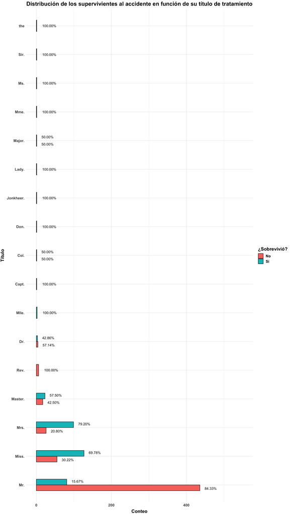

```r
titanic |>
  group_by(Title) |>
  count(Survived) |>
  mutate(porc = n / sum(n)) |>
  mutate(conteo = n) |>
  ggplot(aes(x = reorder(Title, -conteo), y = conteo, fill = Survived)) +
  geom_bar(stat = "identity", position = "dodge", color = "black", width = 0.4) +
  labs(title = "Distribución de los supervivientes al accidente en función de su título de tratamiento", x = "Título", y = "Conteo") +
  scale_y_continuous(limit = c(0,550)) +
  theme_minimal() +
  theme(text = element_text(face = "bold", size = 15), plot.title = element_text(hjust = 0.5),
  axis.title.x = element_text(vjust = -0.5), axis.title.y = element_text(vjust = 2)) +
  scale_fill_discrete(name = "¿Sobrevivió?", labels = c("No", "Sí")) +
  geom_text(aes(label = scales::percent(porc)), position = position_dodge(width = 0.5), hjust = -0.4, size = 4) +
  coord_flip()
```

Algunas apreciaciones a la luz del gráfico:

- Los títulos de tratamiento mayoritarios son `Mr.`, `Miss.`, `Mrs.` y `Master`.
- La gran mayoría de `Mr.` fallecieron en el accidente (casi un 85 %), pero las proporciones se invierten para las `Miss.` y para las `Mrs.` Para estas categorías, **el 80 y el 70 %** de `Mrs.` y `Miss.`, respectivamente, **sobrevivieron**. Esto puede ser debido, fundamentalmente, a que los primeros grupos de personas en ser **evacuados** de la embarcación fueron las **mujeres** y los **niños**.
- La categoría `Master.` se empleaba antaño para hombres jóvenes. Para este caso, también hubo **más supervivientes que fallecidos**, por el mismo motivo que en el caso anterior.

Con ello en mente, se optará en la fase de **recategorización** por **mantener** estas **cuatro** categorías y agrupar el resto en un `Others`.

### Variable Sex

```r
titanic |>
  count(Sex, sort = TRUE) |>
  mutate(porc = 100*n/sum(n))
```

```
# A tibble: 2 × 3
  Sex        n  porc
  <fct>  <int> <dbl>
1 male     577  64.8
2 female   314  35.2
```

La variable `Sex` presenta **2 modalidades**, por lo que se trata de una **variable binaria**. La **proporción** de los registros favorece a los individuos de sexo **masculino**, con un **65 %** sobre el total (2/3). Comprobemos ahora su afectación sobre nuestra variable objetivo.

```r
titanic |>
  group_by(Sex) |>
  count(Survived) |>
  mutate(porc = 100*n/sum(n)) |>
  ungroup()
```

```
# A tibble: 4 × 4
  Sex    Survived     n  porc
  <fct>  <fct>    <int> <dbl>
1 male   0          468  81.1
2 male   1          109  18.9
3 female 0           81  25.8
4 female 1          233  74.2
```

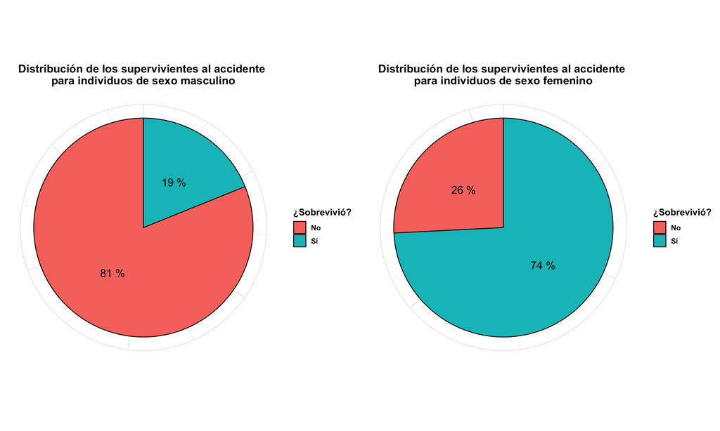

```r
hombre <-
  titanic |>
  filter(Sex == "male") |>
  group_by(Survived) |>
  summarise(n = n()) |>
  ggplot(aes(x = "", y = n, fill = Survived)) +
  geom_bar(stat = "identity", color = "black") +
  coord_polar("y") + geom_text(aes(label = paste(100 * round(n/577, 2), "%")),
                               position = position_stack(vjust = 0.5), check_overlap = T, size = 5) +
  labs(x = NULL, y = NULL, fill = NULL, title = "Distribución de los supervivientes al accidente \npara individuos de sexo masculino") +
  theme_minimal() +
  theme(axis.line = element_blank(), text = element_text(face = "bold", size = 12), axis.text = element_blank(),
        axis.ticks = element_blank(), plot.title = element_text(hjust = 0.5)) +
  scale_fill_discrete(name = "¿Sobrevivió?", labels = c("No", "Sí"))

mujer <-
  titanic |>
  filter(Sex == "female") |>
  group_by(Survived) |>
  summarise(n = n()) |>
  ggplot(aes(x = "", y = n, fill = Survived)) +
  geom_bar(stat = "identity", width = 2, color = "black") +
  coord_polar("y") + geom_text(aes(label = paste(100 * round(n/314, 2), "%")),
                               position = position_stack(vjust = 0.5), check_overlap = T, size = 5) +
  labs(x = NULL, y = NULL, fill = NULL, title = "Distribución de los supervivientes al accidente \npara individuos de sexo femenino") +
  theme_minimal() +
  theme(axis.line = element_blank(), text = element_text(face = "bold", size = 12), axis.text = element_blank(),
        axis.ticks = element_blank(), plot.title = element_text(hjust = 0.5)) +
  scale_fill_discrete(name = "¿Sobrevivió?", labels = c("No", "Sí"))

Rmisc:::multiplot(hombre, mujer, cols = 2)
```

- Esta variable está **muy desbalanceada**. Cerca de **2/3** de los registros pertenecen únicamente al **sexo masculino** (`Male`).
- De esta variable podemos sacar conclusiones muy similares a las de la variable `Title`. En definitiva, como las **mujeres y los niños** fueron los **primeros** en abandonar la embarcación, tuvieron también **mayores posibilidades de sobrevivir**.

En la fase recategorización se deberá tomar la decisión de eliminar una de las dos variables: `Title` o `Sex`. Ambas explican cuestiones muy similares.

### Variable SibSp

```r
titanic |>
  count(SibSp, sort = TRUE) |>
  mutate(porc = 100*n/sum(n))
```

```
# A tibble: 7 × 3
  SibSp     n   porc
  <fct> <int>  <dbl>
1 0       608 68.2
2 1       209 23.5
3 2        28  3.14
4 4        18  2.02
5 3        16  1.80
6 8         7  0.786
7 5         5  0.561
```

La variable `SibSp` presenta **7 modalidades**. Además, tan solo **una** de ellas acapara el **68 %** del total de los registros. Comprobemos ahora su afectación sobre nuestra variable objetivo.

```r
titanic |>
  group_by(SibSp) |>
  count(Survived) |>
  mutate(porc = 100*n/sum(n)) |>
  ungroup()
```

```
# A tibble: 12 × 4
   SibSp Survived     n  porc
   <fct> <fct>    <int> <dbl>
 1 1     0           97  46.4
 2 1     1          112  53.6
 3 0     0          398  65.5
 4 0     1          210  34.5
 5 3     0           12  75
 6 3     1            4  25
 7 4     0           15  83.3
 8 4     1            3  16.7
 9 2     0           15  53.6
10 2     1           13  46.4
11 5     0            5 100
12 8     0            7 100
```

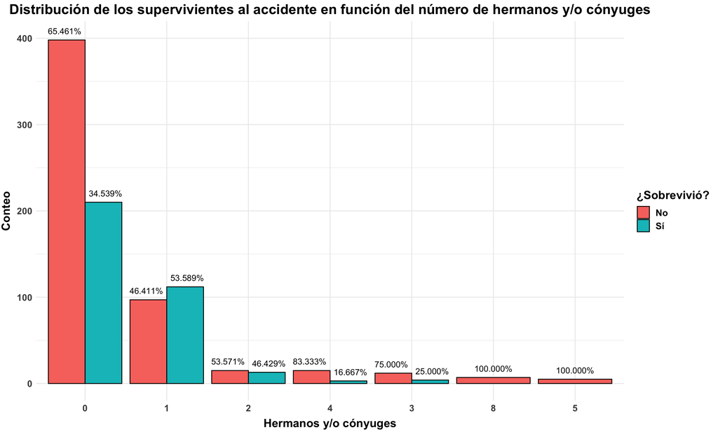

```r
titanic |>
  group_by(SibSp) |>
  count(Survived) |>
  mutate(porc = n / sum(n)) |>
  mutate(conteo = n) |>
  ggplot(aes(x = reorder(SibSp, -conteo), y = conteo, fill = Survived)) +
  geom_col(position = "dodge", color = "black") +
  labs(title = "Distribución de los supervivientes al accidente en función del número de hermanos y/o cónyuges", x = "Hermanos y/o cónyuges", y = "Conteo") +
  scale_y_continuous(limit = c(0,400)) +
  theme_minimal() +
  theme(text = element_text(face = "bold", size = 15), plot.title = element_text(hjust = 0.5),
  axis.title.x = element_text(vjust = -0.5), axis.title.y = element_text(vjust = 2)) +
  scale_fill_discrete(name = "¿Sobrevivió?", labels = c("No", "Sí")) +
  geom_text(aes(label = scales::percent(porc)), position = position_dodge(width = 1), vjust = -1)
```

Algunas apreciaciones a la luz del gráfico:

- La categoría `0` es la **mayoritaria**, y mantiene una distribución **muy similar** a la de la variable objetivo **(65 % / 35 %)**.
- La categoría `1` es la única categoría en donde el **porcentaje de supervivientes** es **mayor** que el de fallecidos. Parece ser que las personas que embarcaron con su pareja o con su hermano finalmente tuvieron más posibilidades de sobrevivir.
- El resto de categorías son **poco representativas** y mantienen una distribución **similar** en donde el porcentaje de pasajeros fallecidos supera al de supervivientes.

Con ello en mente, se optará en la fase de **recategorización** por:

- Mantener las categorías `0` y `1` tal y como están.
- Agrupar las categorías `2`, `3`, `4`, `5` y `8` en una sola.

### Variable Parch

```r
titanic |>
  count(Parch, sort = TRUE) |>
  mutate(porc = 100*n/sum(n))
```

```
# A tibble: 7 × 3
  Parch     n   porc
  <fct> <int>  <dbl>
1 0       678 76.1
2 1       118 13.2
3 2        80  8.98
4 5         5  0.561
5 3         5  0.561
6 4         4  0.449
7 6         1  0.112
```

La variable `Parch` presenta **7 modalidades**. Además, tan solo **una** de ellas acapara el **76 %** del total de los registros. Comprobemos ahora su afectación sobre nuestra variable objetivo.

```r
titanic |>
  group_by(Parch) |>
  count(Survived) |>
  mutate(porc = 100*n/sum(n)) |>
  ungroup()
```

```
# A tibble: 12 × 4
   Parch Survived     n  porc
   <fct> <fct>    <int> <dbl>
 1 0     0          445  65.6
 2 0     1          233  34.4
 3 1     0           53  44.9
 4 1     1           65  55.1
 5 2     0           40  50
 6 2     1           40  50
 7 5     0            4  80
 8 5     1            1  20
 9 3     0            2  40
10 3     1            3  60
11 4     0            4 100
12 6     0            1 100
```

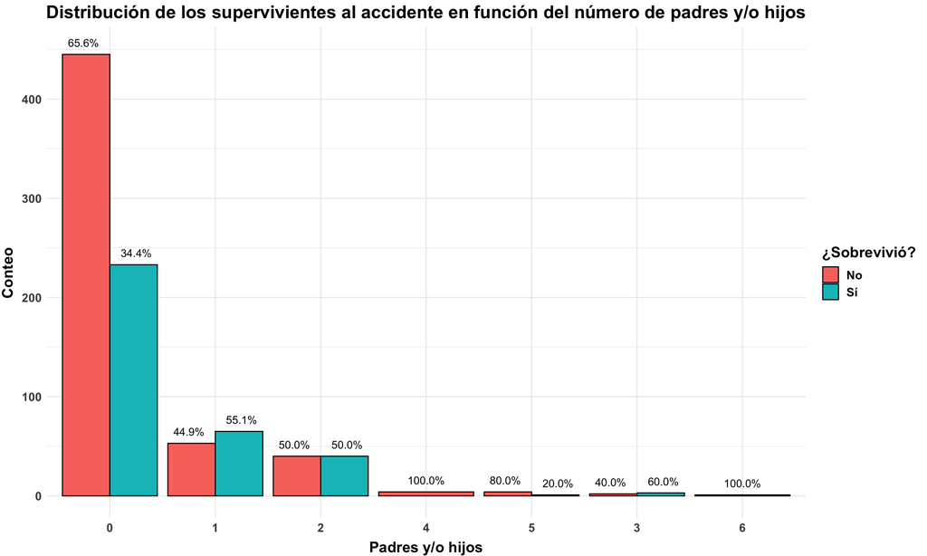

```r
titanic |>
  group_by(Parch) |>
  count(Survived) |>
  mutate(porc = n / sum(n)) |>
  mutate(conteo = n) |>
  ggplot(aes(x = reorder(Parch, -conteo), y = conteo, fill = Survived)) +
  geom_col(position = "dodge", color = "black") +
  labs(title = "Distribución de los supervivientes al accidente en función del número de padres y/o hijos", x = "Padres y/o hijos", y = "Conteo") +
  scale_y_continuous(limit = c(0,450)) +
  theme_minimal() +
  theme(text = element_text(face = "bold", size = 15), plot.title = element_text(hjust = 0.5),
  axis.title.x = element_text(vjust = -0.5), axis.title.y = element_text(vjust = 2)) +
  scale_fill_discrete(name = "¿Sobrevivió?", labels = c("No", "Sí")) +
  geom_text(aes(label = scales::percent(porc)), position = position_dodge(width = 1), vjust = -1)
```

Con ello en mente, se optará en la fase de **recategorización** por:

- Mantener las categorías `0`, `1` y `2` tal y como están.
- Agrupar las categorías `3`, `4`, `5` y `6` en una sola.

### Variable Ticket

```r
titanic |>
  count(Ticket, sort = TRUE) |>
  mutate(porc = 100*n/sum(n))
```

```
# A tibble: 681 × 3
   Ticket           n  porc
   <fct>        <int> <dbl>
 1 347082           7 0.786
 2 1601             7 0.786
 3 CA. 2343         7 0.786
 4 3101295          6 0.673
 5 CA 2144          6 0.673
 6 347088           6 0.673
 7 382652           5 0.561
 8 S.O.C. 14879     5 0.561
 9 349909           4 0.449
10 347077           4 0.449
# … with 671 more rows
```

La variable `Ticket` presenta **681 modalidades**, prácticamente una por cada pasajero en nuestro dataset. Dado que es similar a una **variable identificador**, *a priori* no parece interesante el mantenerla como tal. En la fase de **recategorización** se optará por **eliminar** esta variable.

### Variable Cabin

```r
titanic |>
  count(Cabin, sort = TRUE) |>
  mutate(porc = 100*n/sum(n))
```

```
# A tibble: 148 × 3
   Cabin           n   porc
   <fct>       <int>  <dbl>
 1 <NA>          687 77.1
 2 G6              4  0.449
 3 C23 C25 C27     4  0.449
 4 B96 B98         4  0.449
 5 F33             3  0.337
 6 E101            3  0.337
 7 F2              3  0.337
 8 D               3  0.337
 9 C22 C26         3  0.337
10 C123            2  0.224
# … with 138 more rows
```

A pesar de que, obviamente, no disponemos de la información, sí que podría resultar interesante el consultar un mapa en el que aparezca la **localización** por sectores de todos los **camarotes**. Si lo tuviéramos a mano, podríamos **agrupar el código de los camarotes** en función de la **cercanía** o **lejanía** a las **áreas de evacuación** e incluir estos clústeres en nuestro modelo.

### Variable Embarked

```r
titanic |>
  count(Embarked, sort = TRUE) |>
  mutate(porc = 100*n/sum(n))
```

```
# A tibble: 4 × 3
  Embarked     n   porc
  <fct>    <int>  <dbl>
1 S          644 72.3
2 C          168 18.9
3 Q           77  8.64
4 <NA>         2  0.224
```

La variable `Embarked` presenta **4 modalidades**. Además, tan solo **una** de ellas acapara el **72 %** del total de los registros. Comprobemos ahora su afectación sobre nuestra variable objetivo.

```r
titanic |>
  group_by(Embarked) |>
  count(Survived) |>
  mutate(porc = 100*n/sum(n)) |>
  ungroup()
```

```
# A tibble: 7 × 4
  Embarked Survived     n  porc
  <fct>    <fct>    <int> <dbl>
1 S        0          427  66.3
2 S        1          217  33.7
3 C        0           75  44.6
4 C        1           93  55.4
5 Q        0           47  61.0
6 Q        1           30  39.0
7 <NA>     1            2 100
```

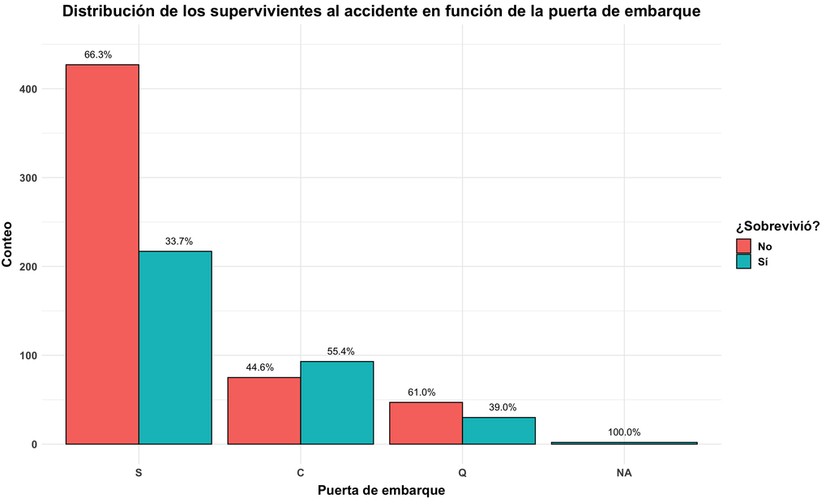

```r
titanic |>
  group_by(Embarked) |>
  count(Survived) |>
  mutate(porc = n / sum(n)) |>
  mutate(conteo = n) |>
  ggplot(aes(x = reorder(Embarked, -conteo), y = conteo, fill = Survived)) +
  geom_col(position = "dodge", color = "black") +
  labs(title = "Distribución de los supervivientes al accidente en función de la puerta de embarque", x = "Puerta de embarque", y = "Conteo") +
  scale_y_continuous(limit = c(0,450)) +
  theme_minimal() +
  theme(text = element_text(face = "bold", size = 15), plot.title = element_text(hjust = 0.5),
  axis.title.x = element_text(vjust = -0.5), axis.title.y = element_text(vjust = 2)) +
  scale_fill_discrete(name = "¿Sobrevivió?", labels = c("No", "Sí")) +
  geom_text(aes(label = scales::percent(porc)), position = position_dodge(width = 1), vjust = -1)
```

Algunas apreciaciones a la luz del gráfico:

- La mayoría de pasajeros embarcaron por la puerta `S` (Southampton). Además, esta categoría mantiene una distribución **muy similar** a la de nuestra variable objetivo **(65 % / 35 %)**.
- La categoría `C` (Cherbourg) es la única en la que el porcentaje de supervivientes supera al de fallecidos. Es posible que los pasajeros que accedieran por esta puerta estuvieran ubicados en camarotes cercanos a los puntos de extracción.
- La categoría `Q` (Queenstown) es la minoritaria, y también mantiene una distribución **muy similar** a la de nuestra variable objetivo **(65 % / 35 %)**.

Con ello en mente, se optará en la fase de **recategorización** por:

- Mantener las categorías `S`, `C` y `Q` tal y como están.
- Agrupar los datos ausentes `NA` en `C`.

### Dependencia entre variables cualitativas

Para terminar, comprobaremos a continuación los posibles **problemas de independencia** entre nuestras variables **cualitativas** respecto de la objetivo. Para ello, se ejecutará una **prueba** $\chi^2$ de **independencia** para comprobar si las variables predictoras cualitativas son **dependientes** o no de nuestra **variable objetivo**. Con un nivel de significación ($\alpha$) = 0.05, si el p-valor < 0.05, rechazaríamos la **hipótesis nula de independencia** a ese mismo nivel de significación.

```r
chisq <-
  tibble("variable" = titanic |> select(where(is.factor)) |> names(),
         "p_value" = titanic |> select(where(is.factor)) |>
           map_dbl(.f = function(x) { chisq.test(titanic$Survived, x)$p.value}))
chisq |> arrange(desc(p_value))
```

```
# A tibble: 8 × 2
  variable   p_value
  <chr>        <dbl>
1 Cabin    1.84e-  1
2 Ticket   1.15e-  2
3 Parch    9.70e-  5
4 Embarked 1.77e-  6
5 SibSp    1.56e-  6
6 Pclass   4.55e- 23
7 Sex      1.20e- 58
8 Survived 7.35e-195
```

```r
chisq |> filter(p_value > 0.05)
```

```
# A tibble: 1 × 2
  variable p_value
  <chr>      <dbl>
1 Cabin      0.184
```

A la luz de los resultados, hay evidencia empírica suficiente para **rechazar al 5 % de nivel de significación** la **hipótesis nula** (H0) que aseguraba la **independencia** de nuestras variables predictoras respecto de la objetivo, excepto para la variable `Cabin`. Por tanto, al 5 % de significación, **no rechazamos** o **aceptamos** la hipótesis alternativa de **dependencia** entre predictoras y objetivo.

Debido a que la variable `Cabin` ya iba a ser **eliminada** por su **elevado número de datos ausentes**, no habrá problema alguno.

## Variables cuantitativas

### Variable PassengerId

```r
titanic |>
  count(PassengerId, sort = TRUE) |>
  mutate(porc = 100*n/sum(n))
```

```
# A tibble: 891 × 3
   PassengerId     n  porc
         <dbl> <int> <dbl>
 1           1     1 0.112
 2           2     1 0.112
 3           3     1 0.112
 4           4     1 0.112
 5           5     1 0.112
 6           6     1 0.112
 7           7     1 0.112
 8           8     1 0.112
 9           9     1 0.112
10          10     1 0.112
# … with 881 more rows
```

### Variable Age

```r
titanic |>
  drop_na(Age) |>
  summarise(min_lead = min(Age), max_lead = max(Age))
```

```
# A tibble: 1 × 2
  min_lead max_lead
     <dbl>    <dbl>
1     0.42       80
```

```r
titanic |>
  count(Age, sort = TRUE) |>
  mutate(porc = 100*n/sum(n), cumul = cumsum(porc))
```

```
# A tibble: 89 × 4
     Age     n  porc cumul
   <dbl> <int> <dbl> <dbl>
 1    NA   177 19.9   19.9
 2    24    30  3.37  23.2
 3    22    27  3.03  26.3
 4    18    26  2.92  29.2
 5    19    25  2.81  32.0
 6    28    25  2.81  34.8
 7    30    25  2.81  37.6
 8    21    24  2.69  40.3
 9    25    23  2.58  42.9
10    36    22  2.47  45.3
# … with 79 more rows
```

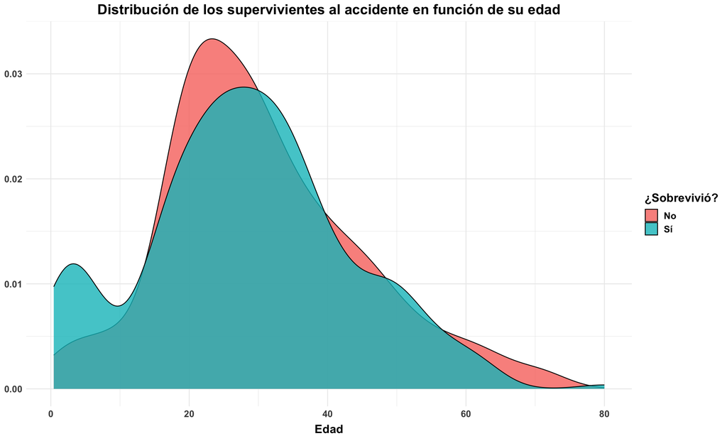

```r
titanic |>
  ggplot(aes(x = Age, fill = Survived)) +
  geom_density(alpha = 0.8) +
  labs(title = "Distribución de los supervivientes al accidente en función de su edad", x = "Edad", y = NULL) +
  scale_fill_discrete(name = "¿Sobrevivió?", labels = c("No", "Sí")) +
  theme_minimal() +
  theme(text = element_text(face = "bold", size = 15), plot.title = element_text(hjust = 0.5),
        axis.title.x = element_text(vjust=-0.5))
```

Algunas apreciaciones a la luz del gráfico:

- En este gráfico de distribuciones podemos observar como el grupo de individuos con **mayor porcentaje de supervivencia** se corresponde en mayor medida con el rango etario de **menor edad** (0-10 años). Por contra, gran parte de los pasajeros **fallecidos** se sitúan en un rango entre los **20 y los 30 años**. Esto es debido fundamentalmente a que los **niños** junto con sus madres fueron los **primeros en ser evacuados**. Además, los pasajeros **hombres** con edades comprendidas entre los **20 y los 30 años** eran el grueso de la tripulación a bordo del barco, y los que fueron evacuados en último lugar, por lo que resulta coherente que sean el rango etario con **más porcentaje de fallecimientos**.
- Para el **rango etario 60-80**, que es el minoritario, también nos encontramos con un alto porcentaje de fallecidos.

Con ello en mente, se optará en la fase de **recategorización** (al menos para Árboles) por transformar la variable cuantitativa `Age` en una *pseudo*-cualitativa por medio de la creación de **rangos etarios**. Concretamente, se optará por la creación de **cinco grupos de edad**: de **0 a 15 años**, de **15 a 30 años**, de **30 a 45 años**, de **45 a 60 años** y de **60 a 80 años**. A los **datos ausentes** lo más seguro es que se les acaba **imputando la media** (o la **moda** en el caso de que se recategorice en forma de rangos etarios).

### Variable Fare

```r
titanic |>
  drop_na(Fare) |>
  summarise(min_lead = min(Fare), max_lead = max(Fare))
```

```
# A tibble: 1 × 2
  min_lead max_lead
     <dbl>    <dbl>
1        0     512.
```

Como se puede observar, la variable `Fare` incluye registros de individuos con tarifas que abarcan desde los **0 $** hasta los **512 $**. Veamos ahora cuál es el peso sobre el total de cada uno de los tipos de tarifa.

```r
titanic |>
  count(Fare, sort = TRUE) |>
  mutate(porc = 100*n/sum(n), cumul = cumsum(porc))
```

```
# A tibble: 248 × 4
    Fare     n  porc cumul
   <dbl> <int> <dbl> <dbl>
 1  8.05    43  4.83  4.83
 2 13       42  4.71  9.54
 3  7.90    38  4.26 13.8
 4  7.75    34  3.82 17.6
 5 26       31  3.48 21.1
 6 10.5     24  2.69 23.8
 7  7.92    18  2.02 25.8
 8  7.78    16  1.80 27.6
 9  0       15  1.68 29.3
10  7.23    15  1.68 31.0
# … with 238 more rows
```

La **gran mayoría** de registros se corresponden con **tarifas relativamente baratas**. Las tarifas para camarotes **caros** son **minoritarias**.

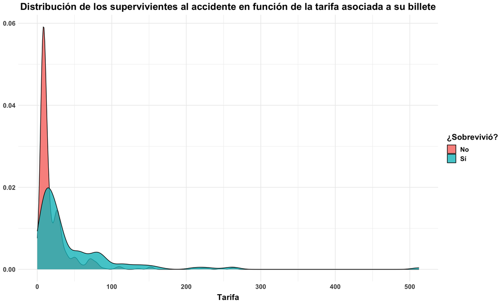

```r
titanic |>
  ggplot(aes(x = Fare, fill = Survived)) +
  geom_density(alpha = 0.8) +
  labs(title = "Distribución de los supervivientes al accidente en función de la tarifa asociada a su billete", x = "Tarifa", y = NULL) +
  scale_fill_discrete(name = "¿Sobrevivió?", labels = c("No", "Sí")) +
  theme_minimal() +
  theme(text = element_text(face = "bold", size = 15), plot.title = element_text(hjust = 0.5),
        axis.title.x = element_text(vjust=-0.5))
```

Algunas apreciaciones a la luz del gráfico:

- En este gráfico de distribuciones podemos observar como **a menor gasto** en concepto de tarifa, **mayor porcentaje de fallecimiento**.
- A partir de los **25 $**, el porcentaje de supervivientes **supera** al de fallecidos en todo momento.

Con ello en mente, se optará en la fase de **recategorización** (al menos para Árboles) por transformar la variable cuantitativa `Fare` en una *pseudo*-cualitativa por medio de la creación de **categorías**. Concretamente, se optará por la creación de **dos categorías**: de **0 a 20 $** y de **más de 20 $** en concepto de tarifa.

### Colinealidad

Para terminar, comprobaremos a continuación los posibles **problemas de colinealidad** entre nuestras variables **numéricas**.

```r
library(corrr)
cor_matrix <-
  titanic |>
  drop_na() |>
  select(where(is.numeric)) |>
  cor() |> round(2)
cor_matrix
```

```
            PassengerId   Age  Fare
PassengerId        1.00  0.03  0.03
Age                0.03  1.00 -0.09
Fare               0.03 -0.09  1.00
```

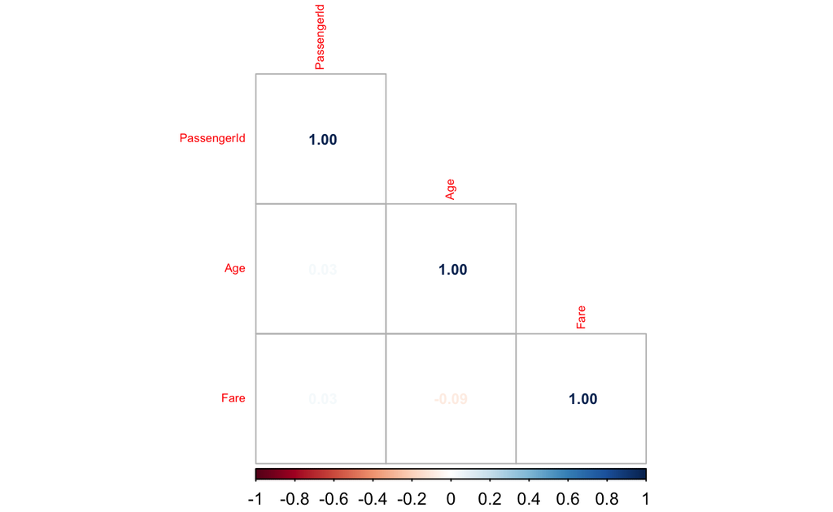

```r
library(corrplot)
cor_matrix |>
  corrplot(method = "number", tl.cex = 0.55, number.cex = 0.7, type = "lower")
```

Según la matriz de correlaciones, **no parece existir** una **correlación elevada** entre ninguna variable.

# Fase 1 y 3: Muestreo y modificación de los datos

Tras la fase de exploración de los datos, continuaremos con las fases de **muestreo** y **modificación** de los datos. Dado que nuestro dataset contiene tan solo **891 observaciones**, no será necesario realizar muestreo (nos quedaríamos prácticamente sin filas si lo hacemos). Por otro lado, **iremos fijando semilla** a fin de poder sacar conclusiones de los resultados de nuestros distintos modelos.

En segundo lugar, para la fase de **modificación** de los datos, consideraremos **dos apartados** principales. Uno primero en donde se ejecutarán las **modificaciones estructurales** que afecten a toda las base de datos (transformar variables a factores, problemas de codificación o de rango, variables que no aportan, creación de variables en general, etc.), y uno segundo en donde se llevarán a cabo aquellas **modificaciones** que afecten **a cada algoritmo en concreto** a modo de **receta** (normalización para la métrica, recategorización, tratamiento de outliers/ausentes, dummyficación, etc.).

## Modificaciones estructurales sobre conjuntos test y train/validación

En este caso, como **las particiones ya están realizadas**, vamos a **bindear** los subconjuntos y a aplicarles a ambos las **modificaciones estructurales** para que tengan la **misma forma**. Además, dado que en test no existe una columna con nuestra variable objetivo, vamos a **crearla artificialmente** y a **rellenarla** con **NA**.

```r
# Cargamos ambas particiones
titanic_train <- read_csv("/Users/leztin/Desktop/DATOS/titanic_train.csv")
titanic_test <- read_csv("/Users/leztin/Desktop/DATOS/titanic_test.csv")

# Creamos en test una columna con la variable objetivo `Survived`
titanic_test$Survived <- NA

# Bindeamos ambos subconjuntos y les aplicamos las modificaciones estructurales
titanic_complete <-
  rbind(titanic_train, titanic_test) |>
  mutate(Survived = as.character(Survived),
         Pclass = as.character(Pclass),
         SibSp = as.character(SibSp),
         Parch = as.character(Parch)) |>
  separate(Name, sep = ",", into = c("Surname", "Title")) |>
  separate(Title, sep = " ", into = c("Name", "Title")) |>
  select(-c(Surname, Name, Ticket, Cabin, PassengerId)) |>
  mutate(across(where(is.character), as_factor)) |>
  mutate(Pclass = factor(Pclass, levels = c("3", "2", "1"),
                         ordered = TRUE))
```

## División de particiones

### Conjuntos train y test

Tras **homogeneizar** los subconjuntos de train y test, los volvemos a **subdividir tal y como se encontraban en origen**.

```r
titanic_train <- titanic_complete[1:891,]
titanic_test <- titanic_complete[892:1309,]
```

## Modificaciones dentro de la receta

### Receta para el algoritmo KNN

#### Aplicación de roles

Tras las particiones, **definimos la receta**, indicándole el conjunto donde tenemos validación y train, y enfrentamos nuestra variable objetivo `Survived` con todas las demás. Después, **asignamos posibles roles**, sujetos a modificación, que nos permitan diferenciar acciones entre las variables.

```r
# Receta
titanic_rec_knn <-
  # Fórmula y datos
  recipe(data = titanic_train, Survived ~ .)|>
  # Roles
  add_role(where(is.factor), new_role = "cualitativa") |>
  add_role(where(is.numeric), new_role = "cuantitativa") |>
  add_role(Sex, new_role = "binaria") |>
  add_role(Fare, new_role = "mediana") |>
  add_role(all_predictors()  & !Fare, new_role = "moda")
```

#### Reagrupación de las variables cualitativas

En este apartado, **reagrupamos** las variables **cualitativas** con `step_mutate` con lo definido en la fase de exploración. Para el **algoritmo de clasificación KNN**, cuanto más **agrupadas** estén este tipo de categorías, **mejor**.

```r
titanic_rec_knn <-
  titanic_rec_knn |>
  step_other(Title,
                threshold = 0.01, other = "Others") |>
  step_mutate(SibSp =
                fct_collapse(SibSp,
                             More_than_one = c("2", "3", "4", "5", "8"))) |>
  step_mutate(Parch =
                fct_collapse(Parch,
                             More_than_two = c("3", "4", "5", "6"))) |>
  step_mutate(Embarked =
                fct_collapse(Embarked,
                             C = c("C", "NA")))
```

#### Recategorización de las variables cuantitativas

En el algoritmo de clasificación **KNN**, la **recategorización** de las variables **cuantitativas no** es estrictamente **necesaria**. Por tanto, en este receta, del total de variables cuantitativas, únicamente vamos a agrupar mediante **rango etarios** la variable `age`, para facilitar la posible interpretación posterior de los resultados. Tras ello, la convertimos a **factor**.

```r
titanic_rec_knn <-
  titanic_rec_knn |>
    step_mutate(Age =
                cut(Age,
                    breaks = c(0, 15, 30, 45, 60, 80),
                    labels = c("0-15", "16-30", "31-45", "46-60", "61-80"))) |>
    step_mutate(Age = factor(Age))
```

#### Outliers

```r
box1 <-
  ggplot(titanic, aes(Survived, Age)) +
  geom_boxplot() +
  theme_minimal() +
  coord_flip()
box2 <-
  ggplot(titanic, aes(Survived, Fare)) +
  geom_boxplot() +
  theme_minimal() +
  coord_flip()

Rmisc:::multiplot(box1, box2)
```

[output not shown]

```r
abs(scores(titanic$Fare, type = "mad"))
```

```r
titanic_rec_knn <-
  titanic_rec_knn |>
  # Detección de outliers por la mediana
  step_mutate(across(has_role("mediana"), function(x) { ifelse(abs(scores(x, type = "mad")) > 3 & !is.na(x), NA, x) })) |>
  # Imputación de ausentes por la mediana y la moda
  step_impute_median(has_role("mediana")) |>
  step_impute_mode(has_role("moda"))
```

#### Filtro de correlación

Aplicamos el **filtro de correlación** a nuestra única variable **numérica**.

```r
titanic_rec_knn <-
  titanic_rec_knn |>
  step_corr(has_role("mediana"), threshold = 0.9)
```

#### Normalizar por rango

En el caso del algoritmo **KNN**, necesitaremos **normalizar** nuestras variables por rango para que todas tengan **el mismo peso**, **entre 0 y 1**.

```r
titanic_rec_knn <-
  titanic_rec_knn |>
  step_range(all_numeric_predictors(), min = 0, max = 1) |>
  step_other(all_nominal_predictors(), threshold = 0.02)
```

#### Variables dummy

Como esta receta es para el modelo KNN, debemos **dummyficar** nuestras variables cualitativas. Para ello, tomamos **todas las nominales, menos nuestra variable objetivo**.

```r
titanic_rec_knn <-
  titanic_rec_knn |>
  step_dummy(all_nominal(), -all_outcomes())
```

#### Filtro de cero varianza

```r
titanic_rec_knn <-
  titanic_rec_knn |>
  step_zv(all_predictors())
```

#### Sobremuestreo

Como tenemos a la **variable objetivo desbalanceada**, deberemos **sobremuestrear** para que nuestro modelo no solo aprenda de la **clase mayoritaria**. Tras varias pruebas, se ha decidido realizar en la receta un sobremuestreo con `step_rose` del paquete `{themis}`.

```r
titanic_rec_knn <-
  titanic_rec_knn |>
  step_rose(Survived, over_ratio = 0.5)
```

#### Horneado

Por último, **horneamos** nuestra receta para comprobar que todas nuestras **nuevas variables** recategorizadas se hayan creado **correctamente**.

```r
bake(titanic_rec_knn |>  prep(), new_data = NULL)
```

```
# A tibble: 549 × 20
       Fare Pclass_1 Pclass_2 Title_Mrs. Title_Miss. Title_Master.
      <dbl>    <dbl>    <dbl>      <dbl>       <dbl>         <dbl>
 1  0.191     0.219    -0.199    -0.442       0.149       0.211
 2  0.00114  -0.635     0.357     0.246       0.858      -0.259
 3  0.0633    0.0645   -0.525     0.0205     -0.248      -0.0456
 4  0.0865   -0.840     0.189     0.0573      0.943      -0.120
 5  0.0772   -0.671     0.249    -0.278       1.28       -0.000891
 6  0.00863  -0.423     0.170     0.123      -0.0139      0.0547
 7  0.0585    0.0210   -0.395    -0.0251      0.104       0.131
 8  0.0174   -0.552     0.337     0.0469      0.159       0.156
 9  0.0352    0.687     0.892     0.268       0.231       0.184
10 -0.0161   -0.127     0.272     0.0990      0.0363      0.0684
# … with 539 more rows, and 14 more variables: Title_Others <dbl>,
#   Sex_female <dbl>, Age_X16.30 <dbl>, Age_X31.45 <dbl>,
#   Age_X46.60 <dbl>, Age_X61.80 <dbl>, SibSp_X0 <dbl>,
#   SibSp_More_than_one <dbl>, Parch_X1 <dbl>, Parch_X2 <dbl>,
#   Parch_other <dbl>, Embarked_C <dbl>, Embarked_Q <dbl>,
#   Survived <fct>
```

### Receta para el método árboles de clasificación

#### Aplicación de roles

En este segundo apartado repetiremos la receta, pero esta vez adaptada a los **árboles de clasificación**.

```r
# Receta
titanic_rec_arbol <-
  # Fórmula y datos
  recipe(data = titanic_train, Survived ~ .)|>
  # Roles
  add_role(where(is.factor), new_role = "cualitativa") |>
  add_role(where(is.numeric), new_role = "cuantitativa") |>
  add_role(Sex, new_role = "binaria")
```

#### Reagrupación de las variables cualitativas

En este apartado, **reagrupamos** las variables **cualitativas** con `step_mutate`. Para el método de **árboles de clasificación**, no es necesario agrupar en exceso este tipo de variables, por lo que se optará por reclasificar únicamente la variable `Title` en la que había **demasiados títulos con muy poca representación**, y la variable `Embarked` con sus **dos ausentes**.

```r
titanic_rec_arbol <-
  titanic_rec_arbol |>
  step_other(Title,
                threshold = 0.01, other = "Others") |>
  step_mutate(Embarked =
                fct_collapse(Embarked,
                             C = c("C", "NA")))
```

#### Recategorización de las variables cuantitativas

Como esta receta es para el método de **árboles de clasificación**, tenemos que **recategorizar** todas las variables **cuantitativas**. En esta ocasión se ha incluido también la variable `Fare`.

```r
titanic_rec_arbol <-
  titanic_rec_arbol |>
    step_mutate(Age =
                cut(Age,
                    breaks = c(0, 15, 30, 45, 60, 80),
                    labels = c("0-15", "16-30", "31-45", "46-60", "61-80"))) |>
    step_mutate(Fare =
                cut(Fare,
                    breaks = c(0, 20, Inf),
                    labels = c("$0-$20", "$20+"))) |>
    step_mutate(Age = factor(Age),
                Fare = factor(Fare))
```

#### Outliers

```r
Rmisc:::multiplot(box1, box2)
```

[output not shown]

```r
abs(scores(titanic$Fare, type = "mad"))
```

```r
titanic_rec_arbol <-
  titanic_rec_arbol |>
  step_impute_mode(all_predictors())
```

#### Filtro de correlación

Como todas nuestras variables están ahora **recategorizadas** y **convertidas a factor**, **no existen** variables estrictamente **numéricas** a las que aplicar el filtro de correlación.

#### Normalizar por rango

En árboles, **no será necesario normalizar por rango**.

#### Variables dummy

En árboles, **tampoco será necesario dummyficar**.

#### Filtro de cero varianza

```r
titanic_rec_arbol <-
  titanic_rec_arbol |>
  step_zv(all_predictors())
```

#### Sobremuestreo

Como tenemos a la **variable objetivo desbalanceada**, deberemos **sobremuestrear** para que nuestro modelo no solo aprenda de la **clase mayoritaria**. Tras varias pruebas, se ha decidido realizar en la receta un sobremuestreo con `step_upsample` del paquete `{themis}`.

```r
titanic_rec_arbol <-
  titanic_rec_arbol |>
  step_upsample(Survived, over_ratio = 0.5)
```

#### Horneado

Por último, **horneamos** nuestra receta para comprobar que todas nuestras **nuevas variables** recategorizadas se hayan creado **correctamente**.

```r
bake(titanic_rec_arbol |>  prep(), new_data = NULL)
```

```
# A tibble: 891 × 9
   Pclass Title Sex    Age   SibSp Parch Fare   Embarked Survived
   <ord>  <fct> <fct>  <fct> <fct> <fct> <fct>  <fct>    <fct>
 1 3      Miss. female 16-30 8     2     $20+   S        0
 2 2      Mr.   male   16-30 0     0     $0-$20 S        0
 3 3      Mr.   male   16-30 0     0     $0-$20 S        0
 4 3      Mr.   male   16-30 0     0     $0-$20 S        0
 5 3      Mr.   male   31-45 0     0     $0-$20 S        0
 6 3      Mr.   male   16-30 0     0     $0-$20 S        0
 7 1      Mr.   male   46-60 0     0     $20+   S        0
 8 3      Mr.   male   16-30 0     0     $0-$20 C        0
 9 3      Mr.   male   16-30 0     0     $0-$20 S        0
10 3      Miss. female 0-15  4     2     $20+   S        0
# … with 881 more rows
```

### Receta para el método regresión logística

#### Aplicación de roles

Tras las particiones, **definimos la receta**, indicándole el conjunto donde tenemos validación y train, y enfrentamos nuestra variable objetivo `Survived` con todas las demás. Después, **asignamos posibles roles**, sujetos a modificación, que nos permitan diferenciar acciones entre las variables.

```r
# Receta
titanic_rec_reg <-
  # Fórmula y datos
  recipe(data = titanic_train, Survived ~ .)|>
  # Roles
  add_role(where(is.factor), new_role = "cualitativa") |>
  add_role(where(is.numeric), new_role = "cuantitativa") |>
  add_role(Sex, new_role = "binaria") |>
  add_role(Fare, new_role = "mediana") |>
  add_role(all_predictors()  & !Fare, new_role = "moda")
```

#### Reagrupación de las variables cualitativas

Agrupamos lo **mínimo**, como en árboles.

```r
titanic_rec_reg <-
  titanic_rec_reg |>
  step_other(Title,
                threshold = 0.01, other = "Others") |>
  step_mutate(Embarked =
                fct_collapse(Embarked,
                             C = c("C", "NA")))
```

#### Recategorización de las variables cuantitativas

En esta receta, del total de variables cuantitativas, únicamente vamos a agrupar mediante **rango etarios** la variable `age`, para facilitar la posible interpretación posterior de los resultados. Tras ello, la convertimos a **factor**.

```r
titanic_rec_reg <-
  titanic_rec_reg |>
    step_mutate(Age =
                cut(Age,
                    breaks = c(0, 15, 30, 45, 60, 80),
                    labels = c("0-15", "16-30", "31-45", "46-60", "61-80"))) |>
    step_mutate(Age = factor(Age))
```

#### Outliers

```r
Rmisc:::multiplot(box1, box2)
```

[output not shown]

```r
abs(scores(titanic$Fare, type = "mad"))
```

```r
titanic_rec_reg <-
  titanic_rec_reg |>
  # Detección de outliers por la media
  step_mutate(across(has_role("mediana"), function(x) { ifelse(abs(scores(x, type = "mad")) > 3 & !is.na(x), NA, x) })) |>
  # Imputación de ausentes por la media y la moda
  step_impute_median(has_role("mediana")) |>
  step_impute_mode(has_role("moda"))
```

#### Filtro de correlación

Aplicamos el **filtro de correlación** a nuestra única variable **numérica**.

```r
titanic_rec_reg <-
  titanic_rec_reg |>
  step_corr(has_role("mediana"), threshold = 0.9)
```

#### Normalizar por rango

Normalizamos por rango para que todas nuestras variables tengan **el mismo peso**.

```r
titanic_rec_reg <-
  titanic_rec_reg |>
  step_range(all_numeric_predictors(), min = 0, max = 1) |>
  step_other(all_nominal_predictors(), threshold = 0.02)
```

#### Variables dummy

Dummyficamos para **facilitar** posibles posteriores **interpretaciones** de nuestros datos.

```r
titanic_rec_reg <-
  titanic_rec_reg |>
  step_dummy(all_nominal(), -all_outcomes())
```

#### Filtro de cero varianza

```r
titanic_rec_reg <-
  titanic_rec_reg |>
  step_zv(all_predictors())
```

#### Sobremuestreo

Como tenemos a la **variable objetivo desbalanceada**, deberemos **sobremuestrear** para que nuestro modelo no solo aprenda de la **clase mayoritaria**. Tras varias pruebas, se ha decidido realizar en la receta un sobremuestreo con `step_upsample` del paquete `{themis}`.

```r
titanic_rec_reg <-
  titanic_rec_reg |>
  themis::step_upsample(Survived, over_ratio = 0.5)
```

#### Horneado

Por último, **horneamos** nuestra receta para comprobar que todas nuestras **nuevas variables** recategorizadas se hayan creado **correctamente**.

```r
bake(titanic_rec_reg |>  prep(), new_data = NULL)
```

```
# A tibble: 891 × 22
     Fare Survived  Pclass_1 Pclass_2 Title_Mrs. Title_Miss.
    <dbl> <fct>        <dbl>    <dbl>      <dbl>       <dbl>
 1 0.143  0        -7.85e-17   -0.816          0           0
 2 0.0283 0        -7.07e- 1    0.408          1           0
 3 0.0157 0        -7.07e- 1    0.408          0           0
 4 0.0142 0        -7.07e- 1    0.408          0           0
 5 0.0139 0        -7.07e- 1    0.408          0           0
 6 0.0157 0        -7.07e- 1    0.408          0           1
 7 0.0512 0        -7.85e-17   -0.816          0           0
 8 0.0254 0        -7.85e-17   -0.816          0           0
 9 0.0282 0        -7.07e- 1    0.408          0           0
10 0.0541 0        -7.85e-17   -0.816          0           0
# … with 881 more rows, and 16 more variables: Title_Master. <dbl>,
#   Title_Others <dbl>, Sex_female <dbl>, Age_X16.30 <dbl>,
#   Age_X31.45 <dbl>, Age_X46.60 <dbl>, Age_X61.80 <dbl>,
#   SibSp_X0 <dbl>, SibSp_X4 <dbl>, SibSp_X2 <dbl>,
#   SibSp_other <dbl>, Parch_X1 <dbl>, Parch_X2 <dbl>,
#   Parch_other <dbl>, Embarked_C <dbl>, Embarked_Q <dbl>
```

# Fase 4.1: Modelo y Flujo (KNN)

Una vez definida la receta, definimos el **modelo** y lo unimos con nuestra receta creando un **flujo de clasificación**. Se trata de un nuevo modelo con `tune()` para poder definir posteriormente los parámetros de forma **manual**.

```r
# Modelo tuneado
knn_model_tune <-
  nearest_neighbor(mode = "classification", neighbors = tune("k"),
                   weight_func = tune("weight"), dist_power = tune("dist")) |>
  set_engine("kknn")

# Flujo de trabajo
titanic_wflow_knn <-
  workflow() |>
  add_recipe(titanic_rec_knn) |>
  add_model(knn_model_tune)
```

# Fase 5.1: Evaluación en Validación Cruzada V-Folds (KNN) y predicción

Para esta práctica evaluaremos directamente a través del **método de Validación Cruzada V-Folds**, que nos proporcionará además una **métrica media** con la **desviación típica** para cada modelo.

## Creación del grid expandido

Para ello, en primer lugar crearemos un **grid** con la función `expand_grid` que nos permitirá **definir manualmente** los **parámetros** que queramos sin estar condicionados por una función automática. De esta manera, podremos **probar** todas las **combinaciones** que queramos. Tras comprobar varias combinaciones, finalmente nos decantamos por la siguiente.

```r
grid_knn <-
  expand_grid("k" = c(60, 80, 100, 150),
              "weight" = c("inv", "gaussian"),
              "dist" = c(0.01, 2, 5, 15, 20))
grid_knn
```

```
# A tibble: 40 × 3
       k weight    dist
   <dbl> <chr>    <dbl>
 1    60 inv       0.01
 2    60 inv       2
 3    60 inv       5
 4    60 inv      15
 5    60 inv      20
 6    60 gaussian  0.01
 7    60 gaussian  2
 8    60 gaussian  5
 9    60 gaussian 15
10    60 gaussian 20
# … with 30 more rows
```

## Aplicación del proceso de validación

Aplicamos en esta fase el proceso de Validación Cruzada V-Folds.

```r
titanic_cv_folds <- vfold_cv(data = titanic_train, v = 8, repeats = 4, strata = Survived)
titanic_cv_folds
```

```
#  8-fold cross-validation repeated 4 times using stratification
# A tibble: 32 × 3
   splits            id      id2
   <list>            <chr>   <chr>
 1 <split [779/112]> Repeat1 Fold1
 2 <split [779/112]> Repeat1 Fold2
 3 <split [779/112]> Repeat1 Fold3
 4 <split [779/112]> Repeat1 Fold4
 5 <split [779/112]> Repeat1 Fold5
 6 <split [780/111]> Repeat1 Fold6
 7 <split [781/110]> Repeat1 Fold7
 8 <split [781/110]> Repeat1 Fold8
 9 <split [779/112]> Repeat2 Fold1
10 <split [779/112]> Repeat2 Fold2
# … with 22 more rows
```

```r
set.seed(05491)

clusters <- detectCores() - 1
make_cluster <- makeCluster(clusters)
registerDoParallel(make_cluster)

titanic_knn_vf <-
 titanic_wflow_knn |>
  tune_grid(resamples = titanic_cv_folds,
            grid = grid_knn,
            control = control_grid(verbose = TRUE, allow_par = TRUE,
                                   pkgs = c("outliers", "tidyverse")),
            metrics = metric_set(accuracy, sensitivity, specificity, roc_auc))

# Finalizamos clusters
stopCluster(make_cluster)
registerDoSEQ()

titanic_knn_vf |> collect_metrics()
```

```
# A tibble: 160 × 9
       k weight    dist .metric .estimator  mean     n std_err .config
   <dbl> <chr>    <dbl> <chr>   <chr>      <dbl> <int>   <dbl> <chr>
 1    60 gaussian  0.01 accura… binary     0.682    32 0.00555 Prepro…
 2    60 gaussian  0.01 roc_auc binary     0.833    32 0.00743 Prepro…
 3    60 gaussian  0.01 sensit… binary     0.995    32 0.00182 Prepro…
 4    60 gaussian  0.01 specif… binary     0.179    32 0.0154  Prepro…
 5    80 gaussian  0.01 accura… binary     0.678    32 0.00499 Prepro…
 6    80 gaussian  0.01 roc_auc binary     0.836    32 0.00726 Prepro…
 7    80 gaussian  0.01 sensit… binary     0.995    32 0.00182 Prepro…
 8    80 gaussian  0.01 specif… binary     0.170    32 0.0136  Prepro…
 9   100 gaussian  0.01 accura… binary     0.680    32 0.00485 Prepro…
10   100 gaussian  0.01 roc_auc binary     0.837    32 0.00713 Prepro…
# … with 150 more rows
```

## Elección del mejor de los modelos

Con `show_best()` se muestran a continuación los **mejores modelos** según `accuracy`.

```r
# Se muestran los mejores según accuracy
titanic_knn_vf |> show_best("accuracy")
```

```
# A tibble: 5 × 9
      k weight    dist .metric  .estimator  mean     n std_err .config
  <dbl> <chr>    <dbl> <chr>    <chr>      <dbl> <int>   <dbl> <chr>
1    60 gaussian     2 accuracy binary     0.799    32 0.00588 Prepro…
2    80 gaussian     2 accuracy binary     0.794    32 0.00608 Prepro…
3   100 gaussian     2 accuracy binary     0.790    32 0.00605 Prepro…
4    60 gaussian     5 accuracy binary     0.786    32 0.00486 Prepro…
5    80 gaussian     5 accuracy binary     0.781    32 0.00432 Prepro…
```

## Finalización del flujo

Tras elegir el mejor, **finalizamos el flujo con ese modelo elegido** empleando la función `finalize_workflow()`.

```r
# Finalizamos flujo con el mejor modelo según accuracy
best_titanic_knn_vf <-
  titanic_knn_vf |> select_best("accuracy")

final_wflow_knn <-
  titanic_wflow_knn |>
  finalize_workflow(best_titanic_knn_vf)

final_wflow_knn
```

```
══ Workflow ══════════════════════════════════════════════════════════
Preprocessor: Recipe
Model: nearest_neighbor()

── Preprocessor ──────────────────────────────────────────────────────
15 Recipe Steps

• step_other()
• step_mutate()
• step_mutate()
• step_mutate()
• step_mutate()
• step_mutate()
• step_mutate()
• step_impute_median()
• step_impute_mode()
• step_corr()
• ...
• and 5 more steps.

── Model ─────────────────────────────────────────────────────────────
K-Nearest Neighbor Model Specification (classification)

Main Arguments:
  neighbors = 60
  weight_func = gaussian
  dist_power = 2

Computational engine: kknn
```

# Fase 4.2: Modelo y Flujo (Árboles) con poda

A continuación, procederemos con el modelo para la **receta de árboles**. El modelo consistirá en un **árbol de clasificación** que implementaremos con `decision_tree()` y `mode = "classification"`. De nuevo, crearemos el modelo con `tune()` para poder definir posteriormente los parámetros de forma **manual**. Generamos un flujo de trabajo en función del **criterios de impureza de Gini**.

Por otro lado, añadiremos también directamente el parámetro `cost_complexity`, que se usa en la fase de **poda (prune)**, y que introduce un componente **penalizador** para evitar modelos **sobreajustados**.

```r
# Modelo con tres parámetros tuneados
decision_tree_gini <-
  decision_tree(tree_depth = tune("depth"), min_n = tune("min_n"),
                cost_complexity = tune("cost")) |>
  set_engine("rpart") |>
  set_mode("classification")
```

```r
# Flujo de trabajo
titanic_tree_gini_wflow <-
  workflow() |>
  add_recipe(titanic_rec_arbol) |>
  add_model(decision_tree_gini)
```

# Fase 5.2: Evaluación en Validación Cruzada V-Folds (Árboles) y predicción

Para este modelo, volvemos a evaluar a través del **método de Validación Cruzada V-Folds**, que nos proporcionará además una **métrica media** con la **desviación típica** para cada modelo.

## Creación de los grid expandidos

Para ello, en primer lugar crearemos dos **grid** con la función `expand_grid` que nos permitirán **definir manualmente** los **parámetros** que queramos sin estar condicionados por una función automática. De nuevo, tras comprobar varias combinaciones, nos decantaremos finalmente por las siguientes.

```r
grid_tree_gini <-
  expand_grid("depth" = c(2, 4, 6, 8, 10),
              "min_n" = c(10, 50, 100, 150),
              "cost" = 10^c(-5, -3, -2, -0.5))
```

Crearemos en este caso **80 modelos** ($5*4*4$).

## Aplicación del proceso de validación

Aplicamos en esta fase el proceso de **Validación Cruzada V-Folds**.

```r
set.seed(05491)

clusters <- detectCores() - 1
make_cluster <- makeCluster(clusters)
registerDoParallel(make_cluster)

titanic_tree_gini <-
  titanic_tree_gini_wflow |>
  tune_grid(resamples = titanic_cv_folds,
            grid = grid_tree_gini,
            control = control_grid(verbose = TRUE, allow_par = TRUE,
                                   pkgs = c("outliers", "tidyverse"), save_pred = TRUE),
            metrics = metric_set(accuracy, sensitivity,
                                 specificity, roc_auc))

# Finalizamos clusters
stopCluster(make_cluster)
registerDoSEQ()

titanic_tree_gini |> collect_metrics()
```

```
# A tibble: 320 × 9
      cost depth min_n .metric  .estimator  mean     n std_err .config
     <dbl> <dbl> <dbl> <chr>    <chr>      <dbl> <int>   <dbl> <chr>
 1 0.00001     2    10 accuracy binary     0.784    32 0.00471 Prepro…
 2 0.00001     2    10 roc_auc  binary     0.789    32 0.00745 Prepro…
 3 0.00001     2    10 sensiti… binary     0.909    32 0.0145  Prepro…
 4 0.00001     2    10 specifi… binary     0.582    32 0.0235  Prepro…
 5 0.001       2    10 accuracy binary     0.784    32 0.00471 Prepro…
 6 0.001       2    10 roc_auc  binary     0.789    32 0.00745 Prepro…
 7 0.001       2    10 sensiti… binary     0.909    32 0.0145  Prepro…
 8 0.001       2    10 specifi… binary     0.582    32 0.0235  Prepro…
 9 0.01        2    10 accuracy binary     0.781    32 0.00565 Prepro…
10 0.01        2    10 roc_auc  binary     0.786    32 0.00817 Prepro…
# … with 310 more rows
```

## Elección del mejor de los modelos

Como sucedía en el modelo KNN, procedemos a ver los mejores con `show_best()`.

```r
# Mejores modelos según curva roc y accuracy
titanic_tree_gini |>  show_best("roc_auc", n = 10)
```

```
# A tibble: 10 × 9
      cost depth min_n .metric .estimator  mean     n std_err .config
     <dbl> <dbl> <dbl> <chr>   <chr>      <dbl> <int>   <dbl> <chr>
 1 0.00001     4    10 roc_auc binary     0.840    32 0.00815 Preproc…
 2 0.001       4    10 roc_auc binary     0.840    32 0.00815 Preproc…
 3 0.00001     6    10 roc_auc binary     0.839    32 0.00817 Preproc…
 4 0.001       6    10 roc_auc binary     0.837    32 0.00787 Preproc…
 5 0.00001     8    10 roc_auc binary     0.832    32 0.00805 Preproc…
 6 0.001       8    10 roc_auc binary     0.832    32 0.00776 Preproc…
 7 0.00001     8    50 roc_auc binary     0.831    32 0.00731 Preproc…
 8 0.001       8    50 roc_auc binary     0.831    32 0.00731 Preproc…
 9 0.00001    10    50 roc_auc binary     0.831    32 0.00731 Preproc…
10 0.001      10    50 roc_auc binary     0.831    32 0.00731 Preproc…
```

```r
titanic_tree_gini |> show_best("accuracy", n = 10)
```

```
# A tibble: 10 × 9
      cost depth min_n .metric  .estimator  mean     n std_err .config
     <dbl> <dbl> <dbl> <chr>    <chr>      <dbl> <int>   <dbl> <chr>
 1 0.01        6    10 accuracy binary     0.809    32 0.00579 Prepro…
 2 0.01        8    10 accuracy binary     0.809    32 0.00602 Prepro…
 3 0.01       10    10 accuracy binary     0.809    32 0.00602 Prepro…
 4 0.001       6    10 accuracy binary     0.808    32 0.00562 Prepro…
 5 0.00001     6    10 accuracy binary     0.808    32 0.00565 Prepro…
 6 0.01        4    10 accuracy binary     0.808    32 0.00560 Prepro…
 7 0.01        4   100 accuracy binary     0.806    32 0.00546 Prepro…
 8 0.01        6   100 accuracy binary     0.806    32 0.00546 Prepro…
 9 0.01        8   100 accuracy binary     0.806    32 0.00546 Prepro…
10 0.01       10   100 accuracy binary     0.806    32 0.00546 Prepro…
```

## Finalización del flujo

Tras elegir el mejor, **finalizamos el flujo con ese modelo elegido** empleando la función `finalize_workflow()`.

```r
# Finalizamos flujo con el mejor modelo según accuracy
best_titanic_tree_gini <-
  titanic_tree_gini |> select_best("accuracy")

final_wf_tree_gini <-
  titanic_tree_gini_wflow |>
  finalize_workflow(best_titanic_tree_gini)

final_wf_tree_gini
```

```
══ Workflow ══════════════════════════════════════════════════════════
Preprocessor: Recipe
Model: decision_tree()

── Preprocessor ──────────────────────────────────────────────────────
8 Recipe Steps

• step_other()
• step_mutate()
• step_mutate()
• step_mutate()
• step_mutate()
• step_impute_mode()
• step_zv()
• step_upsample()

── Model ─────────────────────────────────────────────────────────────
Decision Tree Model Specification (classification)

Main Arguments:
  cost_complexity = 0.01
  tree_depth = 6
  min_n = 10

Computational engine: rpart
```

# Fase 4.3: Modelo y Flujo (Random Forest)

Para ir finalizando la práctica lanzaremos un **Random Forest**, esto es, una combinación de árboles predictores tal que **cada árbol depende de los valores de un vector aleatorio**, probado **independientemente**, y con la **misma distribución** para cada uno de ellos. Es una modificación sustancial de los métodos de **bagging**, en donde se construyen una larga colección de **árboles no correlacionados** y luego los **promedia**.

```r
# Modelo Random Forest
rf_titanic <-
  rand_forest(mode = "classification",
              mtry = tune("n_pred"),
              min_n = tune("min_n"),
              trees = 1000) |>
  set_engine("ranger", num.threads = 7)

# Flujo de trabajo
titanic_rf_wflow <-
  workflow() |>
  add_recipe(titanic_rec_arbol) |>
  add_model(rf_titanic)
```

# Fase 5.3: Evaluación en Validación Cruzada V-Folds (Random Forest) y predicción

## Creación del grid expandido

```r
grid_rf <-
  expand_grid("n_pred" = c(1, 2, 3),
              "min_n" = c(5, 7, 10, 20, 30, 40))
```

## Aplicación del proceso de validación

```r
set.seed(05491)

clusters <- detectCores() - 1
make_cluster <- makeCluster(clusters)
registerDoParallel(make_cluster)

rf_tune_par <-
  titanic_rf_wflow |>
  tune_grid(resamples = titanic_cv_folds,
            grid = grid_rf,
            metrics = metric_set(accuracy, sensitivity, specificity, roc_auc),
            control = control_grid(verbose = TRUE,
                                   allow_par = TRUE,
                                   pkgs = c("outliers", "tidyverse"),
                                   save_pred = TRUE))

# Finalizamos clusters
stopCluster(make_cluster)
registerDoSEQ()

rf_tune_par |> collect_metrics()
```

```
# A tibble: 72 × 8
   n_pred min_n .metric     .estimator  mean     n std_err .config
    <dbl> <dbl> <chr>       <chr>      <dbl> <int>   <dbl> <chr>
 1      1     5 accuracy    binary     0.824    32 0.00628 Preprocess…
 2      1     5 roc_auc     binary     0.866    32 0.00630 Preprocess…
 3      1     5 sensitivity binary     0.906    32 0.00837 Preprocess…
 4      1     5 specificity binary     0.692    32 0.0139  Preprocess…
 5      1     7 accuracy    binary     0.824    32 0.00578 Preprocess…
 6      1     7 roc_auc     binary     0.866    32 0.00644 Preprocess…
 7      1     7 sensitivity binary     0.905    32 0.00790 Preprocess…
 8      1     7 specificity binary     0.694    32 0.0133  Preprocess…
 9      1    10 accuracy    binary     0.824    32 0.00611 Preprocess…
10      1    10 roc_auc     binary     0.866    32 0.00640 Preprocess…
# … with 62 more rows
```

## Elección del mejor de los modelos y finalización del flujo

```r
# Finalizamos flujo con el mejor modelo según accuracy
best_rf_tune_par <-
  rf_tune_par |> select_best("accuracy")

final_titanic_rf_wflow <-
  titanic_rf_wflow |>
  finalize_workflow(best_rf_tune_par)

final_titanic_rf_wflow
```

```
══ Workflow ══════════════════════════════════════════════════════════
Preprocessor: Recipe
Model: rand_forest()

── Preprocessor ──────────────────────────────────────────────────────
8 Recipe Steps

• step_other()
• step_mutate()
• step_mutate()
• step_mutate()
• step_mutate()
• step_impute_mode()
• step_zv()
• step_upsample()

── Model ─────────────────────────────────────────────────────────────
Random Forest Model Specification (classification)

Main Arguments:
  mtry = 1
  trees = 1000
  min_n = 10

Engine-Specific Arguments:
  num.threads = 7

Computational engine: ranger
```

# Fase 4.4: Modelo y Flujo (Regresión logística)

Para finalizar la práctica lanzaremos una **regresión logística**. En este caso, el modelo no presenta parámetros para tunear, por lo que, en principio, **no sería necesario hacer validación**. En nuestro caso, sí que la haremos para poder **comparar** esta fase con el resto de modelos y así poder **seleccionar el mejor de todos**.

```r
# Regresión logística
logit_mod <-
  logistic_reg() |>
  set_engine("glm")

# Flujo de trabajo
titanic_reg_wflow <-
  workflow() |>
  add_recipe(titanic_rec_reg) |>
  add_model(logit_mod)
```

# Fase 5.3: Evaluación en Validación Cruzada V-Folds (Regresión logística) y predicción

## Aplicación del proceso de validación

```r
set.seed(05491)

clusters <- detectCores() - 1
make_cluster <- makeCluster(clusters)
registerDoParallel(make_cluster)

reg_tune_par <-
  titanic_reg_wflow |>
  tune_grid(resamples = titanic_cv_folds,
            metrics = metric_set(accuracy, sensitivity, specificity, roc_auc),
            control = control_grid(verbose = TRUE,
                                   allow_par = TRUE,
                                   pkgs = c("outliers", "tidyverse"),
                                   save_pred = TRUE))

# Finalizamos clusters
stopCluster(make_cluster)
registerDoSEQ()

reg_tune_par |> collect_metrics()
```

```
# A tibble: 4 × 6
  .metric     .estimator  mean     n std_err .config
  <chr>       <chr>      <dbl> <int>   <dbl> <chr>
1 accuracy    binary     0.808    32 0.00642 Preprocessor1_Model1
2 roc_auc     binary     0.855    32 0.00653 Preprocessor1_Model1
3 sensitivity binary     0.857    32 0.00777 Preprocessor1_Model1
4 specificity binary     0.729    32 0.0120  Preprocessor1_Model1
```

## Elección del mejor de los modelos y finalización del flujo

```r
# Finalizamos flujo con el mejor modelo según specificity (siempre es el mismo)
best_reg_tune_par <-
  reg_tune_par |> select_best("accuracy")

final_titanic_reg_wflow <-
  titanic_reg_wflow |>
  finalize_workflow(best_reg_tune_par)

final_titanic_reg_wflow
```

```
══ Workflow ══════════════════════════════════════════════════════════
Preprocessor: Recipe
Model: logistic_reg()

── Preprocessor ──────────────────────────────────────────────────────
13 Recipe Steps

• step_other()
• step_mutate()
• step_mutate()
• step_mutate()
• step_mutate()
• step_impute_median()
• step_impute_mode()
• step_corr()
• step_range()
• step_other()
• ...
• and 3 more steps.

── Model ─────────────────────────────────────────────────────────────
Logistic Regression Model Specification (classification)

Computational engine: glm
```

# Comparativa final entre modelos: KNN, Árboles, Random Forest y Regresión Logística y predicción para Kaggle

En total en esta práctica se han lanzado cuatro modelos: un **KNN**, un **Árbol**, un **Random Forest** y una **Regresión Logística**. A continuación un resumen de sus métricas para hacer la **comparativa**:

## Métricas de los modelos

```r
# Modelo KNN
titanic_knn_vf |>
  collect_metrics() |>
  filter(.config == pull(select(best_titanic_knn_vf, .config)))
```

```
# A tibble: 4 × 9
      k weight    dist .metric  .estimator  mean     n std_err .config
  <dbl> <chr>    <dbl> <chr>    <chr>      <dbl> <int>   <dbl> <chr>
1    60 gaussian     2 accuracy binary     0.799    32 0.00588 Prepro…
2    60 gaussian     2 roc_auc  binary     0.843    32 0.00658 Prepro…
3    60 gaussian     2 sensiti… binary     0.938    32 0.00583 Prepro…
4    60 gaussian     2 specifi… binary     0.576    32 0.0153  Prepro…
```

```r
# Modelo Árbol Gini
titanic_tree_gini |>
  collect_metrics() |>
  filter(.config == pull(select(best_titanic_tree_gini, .config)))
```

```
# A tibble: 4 × 9
   cost depth min_n .metric     .estimator  mean     n std_err .config
  <dbl> <dbl> <dbl> <chr>       <chr>      <dbl> <int>   <dbl> <chr>
1  0.01     6    10 accuracy    binary     0.809    32 0.00579 Prepro…
2  0.01     6    10 roc_auc     binary     0.824    32 0.00892 Prepro…
3  0.01     6    10 sensitivity binary     0.887    32 0.00830 Prepro…
4  0.01     6    10 specificity binary     0.684    32 0.0136  Prepro…
```

```r
# Modelo Random Forest
rf_tune_par |>
  collect_metrics() |>
  filter(.config == pull(select(best_rf_tune_par, .config)))
```

```
# A tibble: 4 × 8
  n_pred min_n .metric     .estimator  mean     n std_err .config
   <dbl> <dbl> <chr>       <chr>      <dbl> <int>   <dbl> <chr>
1      1    10 accuracy    binary     0.824    32 0.00611 Preprocesso…
2      1    10 roc_auc     binary     0.866    32 0.00640 Preprocesso…
3      1    10 sensitivity binary     0.906    32 0.00805 Preprocesso…
4      1    10 specificity binary     0.693    32 0.0143  Preprocesso…
```

```r
# Modelo Regresión Logística
reg_tune_par |>
  collect_metrics()
```

```
# A tibble: 4 × 6
  .metric     .estimator  mean     n std_err .config
  <chr>       <chr>      <dbl> <int>   <dbl> <chr>
1 accuracy    binary     0.808    32 0.00642 Preprocessor1_Model1
2 roc_auc     binary     0.855    32 0.00653 Preprocessor1_Model1
3 sensitivity binary     0.857    32 0.00777 Preprocessor1_Model1
4 specificity binary     0.729    32 0.0120  Preprocessor1_Model1
```

## Predicción para el mejor modelo: Random Forest

Nos quedamos finalmente con el **Random Forest** (nos salió un **0.77511** de **score** :D)

```r
# Ajuste
titanic_rf_fit <-
  fit(final_titanic_rf_wflow, titanic_train)

# Predicciones
pred_reg <-
  predict(titanic_rf_fit, titanic_test)
summary(pred_reg)
```

```
 .pred_class
 0:283
 1:135
```

```r
# Visualización de las predicciones para cada `PassengerID`
final_pred <-
  data.frame(PassengerID = c(892:1309), pred_reg) |>
  rename(Survived = .pred_class)
head(final_pred)
```

```
  PassengerID Survived
1         892        0
2         893        0
3         894        0
4         895        0
5         896        1
6         897        0
```

```r
# Exportamos nuestro dataframe para subirlo a Kaggle
write.csv(final_pred, file = 'titanic_entrega_rf.csv', row.names = FALSE)
```